# COVID-19 Regional Models for Colorado

05/05/2021

**Prepared by the Colorado COVID-19 Modeling Group**  
Colorado School of Public Health: Andrea Buchwald, Elizabeth Carlton, Debashis Ghosh, Irina Kasarskis, Jonathan Samet, Emily Wu; University of Colorado School of Medicine: Kathryn Colborn; University of Colorado-Boulder Department of Applied Mathematics: Sabina Altus, David Bortz; Colorado State University: Jude Bayham

For Contact: Jon.Samet@CUAnschutz.edu

### **Summary**

Key messages in this report are:

- COVID-19 hospitalizations and estimated new infections are increasing in 9 of the 11 LPHA regions: Central, East Central, Metro, Northeast, Northwest, San Luis Valley, South Central, Southwest, and West Central Partnership. Estimated infections are decreasing in one LPHA region and flat in one LPHA region.
- We estimate more than 1 in 100 people are infectious in East Central, Northeast, South Central, and Southeast regions. Contacts are particularly risky in these regions. These estimates are for April 19th.
- East Central has the lowest percentage of the population that is fully vaccinated (19%). Vaccination is highest in the Central Mountains (40%), Southwest (40%) and West Central Partnership (36%) regions.
- The percent of the population immune due to vaccination and/or infection ranges widely across the state – from 53% in East Central to 30% in Central LPHA region.
- These estimates are based on hospitalization data through 4/26/2021 and vaccination data through 5/2/2021. Due to lags between infection and hospitalization, these estimates do not capture major changes in transmission after approximately April 13th.

### **Introduction**

This report provides the results of epidemic models for regions of Colorado, using methods similar to that used for the state-level model. Estimates are presented for the 11 Local Public Health Agencies (LPHAs) regions in the state and for 8 selected counties with populations that are sufficiently large to allow for county-level estimates. The model results are subject to greater uncertainty than those for the entire state because there are fewer hospitalizations and cases in each region than in the state as a whole. Estimates are most uncertain for the regions with the smallest population size. We use the model as well as COVID-19 hospital,and vaccination data to generate four measures for each region. These measures can be used to gauge the current state of SARS-CoV-2 in each region.

- *The effective reproduction number (Re)* is a measure of how rapidly infections are spreading or declining in a region.
- *Infection prevalence* is an estimate of the portion of the population currently infected and capable of spreading infections. It can be used to gauge how risky contacts are.
- *The percent of the population fully vaccinated to date* is based on data provided by CDPHE and includes all people who have received one dose of Johnson and Johnson or two doses of Pfizer or Moderna vaccine. Because it takes approximately a month to develop immunity, some of these individuals may not yet be immune to the virus.
- *The percent of population estimated to be immune* is estimated from the number of individuals immune due to vaccination combined with the individuals immune due to infection. These estimates account for the time between vaccination and immunity and the efficacy of the vaccine. As the immune population grows, due to vaccination or prior infection, the spread of infection slows.

**Table 1.** The estimated effective reproductive number, prevalence of infections, percent of the population immune and vaccinated to date by region. These metrics are estimated using hospitalization data from the Colorado COVID Patient Hospitalization Surveillance (COPHS). Effective reproductive number (Re) reflects hospitalization data through 04/26/2021. The prevalence of infections and percent of the population immune is estimated for 04/19/2021. The percent vaccinated estimates are based on data provided by CDPHE through 5/02/2021 and reflect the proportion of the population that is fully vaccinated as of that date.

|  | Are infections increasing or decreasing? Re | Are infections increasing or decreasing? Infections are… | How many people are infectious? Prevalence per 100,000 | How many people are infectious? People infectious | Percent of Population Estimated Immune | Percent of Population Fully Vaccinated |
| --- | --- | --- | --- | --- | --- | --- |
| **LPHA Regions** |  |  |  |  |  |  |
| Central | 1.1 | Increasing | 854 | 1 in 117 | 30.4 | 25.3 |
| Central Mountains | 0.8 | Decreasing | 277 | 1 in 361 | 33.8 | 40.1 |
| East Central | 1.2 | Increasing | 3,180 | 1 in 31 | 53.1 | 18.7 |
| Metro | 1.1 | Increasing | 1,002 | 1 in 100 | 36.7 | 34.1 |
| Northeast | 1.1 | Increasing | 1,112 | 1 in 90 | 37.8 | 31.6 |
| Northwest | 1.6 | Increasing | 588 | 1 in 170 | 34.3 | 30.7 |
| San Luis Valley | 1.5 | Increasing | 592 | 1 in 169 | 33.9 | 30.9 |
| South Central | 1.1 | Increasing | 1,560 | 1 in 64 | 43.9 | 28.1 |
| Southeast | 1.0 | Flat | 1,196 | 1 in 84 | 46.2 | 22.8 |
| Southwest | 1.2 | Increasing | 801 | 1 in 125 | 37.7 | 39.8 |
| West Central Partnership | 1.3 | Increasing | 387 | 1 in 258 | 35.4 | 35.5 |
| **Eight select counties** |  |  |  |  |  |  |
| Adams | 1.2 | Increasing | 1,683 | 1 in 59 | 38.9 | 26.1 |
| Arapahoe | 1.1 | Increasing | 1,219 | 1 in 82 | 37.8 | 29.7 |
| Boulder | 1.2 | Increasing | 861 | 1 in 116 | 36.8 | 40.9 |
| Broomfield | 1.2 | Increasing | 425 | 1 in 235 | 34.5 | 42.1 |
| Denver | 1.1 | Increasing | 1,115 | 1 in 90 | 42.2 | 35.5 |
| Douglas | 1.1 | Increasing | 1,085 | 1 in 92 | 33.5 | 34.9 |
| El Paso | 1.2 | Increasing | 907 | 1 in 110 | 30.9 | 24.5 |
| Jefferson plus | 1.1 | Increasing | 542 | 1 in 184 | 35.7 | 39.2 |

Due to the small population sizes of Gilpin and Clear Creek counties, these counties are combined with Jefferson County. Jefferson County comprises 97% of the population in the Jefferson plus county cluster.  
Due to lags between infection and hospitalization, the estimated effective reproductive number (Re) reflects the spread of infections approximately two weeks prior to the data of the last observed hospitalization.  
Immunity from vaccination is based on assumptions that the Moderna and Pfizer vaccines are 52% effective after 14 days and 90% effective a week after the second dose; the Johnson and Johnson vaccine is assumed to be 72% effective 28 days after the first dose. In the model, it is assumed that immunity due to infection wanes after 6 months if an individual has an asymptomatic infection, 12 months if symptomatic. Age distribution of vaccination by region is inferred from state-level age distribution data.

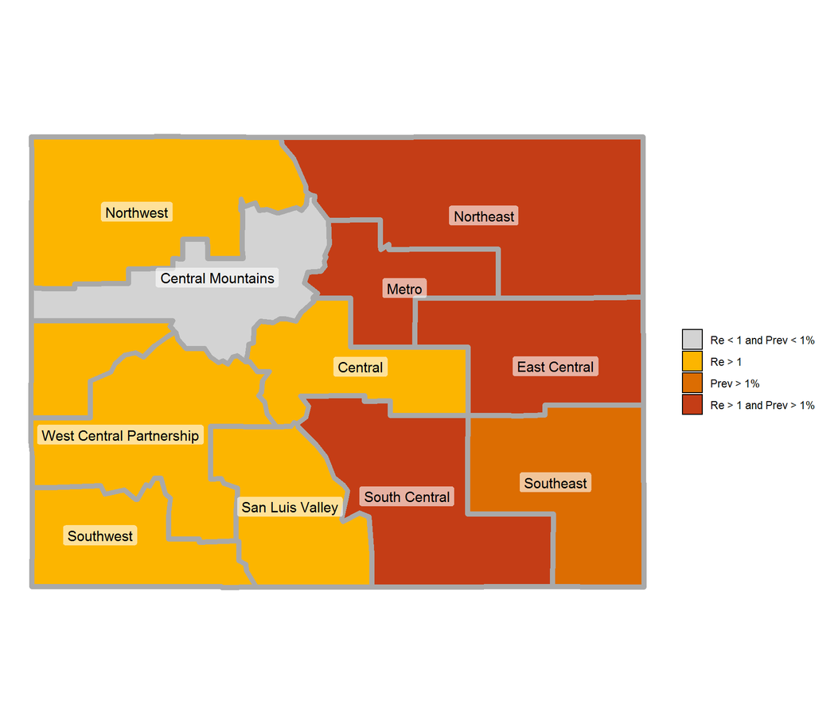

**Figure 1.** Map showing the 11 LPHA regions for which estimates were generated. Regions in yellow (effective reproductive number > 1), orange (prevalence > 1%), or red (both effective reproductive number > 1 and prevalence > 1%) indicate areas of concern.

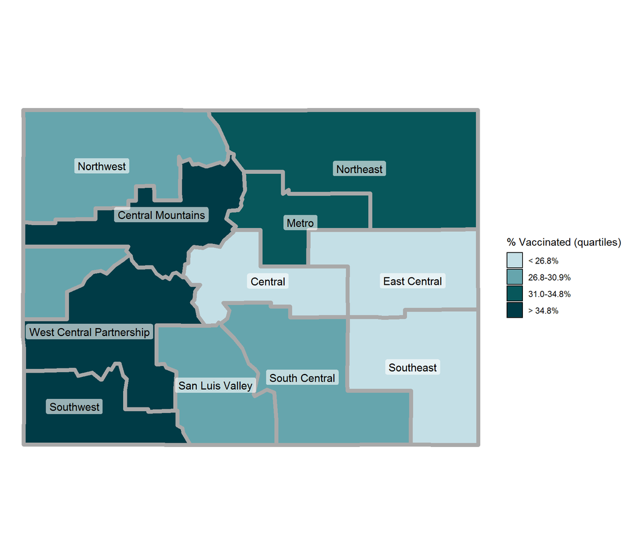

**Figure 2.** Map showing the percent of the population fully vaccinated by LPHA region. Estimates are based on data provided by CDPHE through 5/02/2021 and reflect the proportion of the population that has received one dose of Johnson and Johnson or two doses of Pfizer or Moderna vaccines as of that date. Darker colors indicate a higher proportion of vaccinated residents.

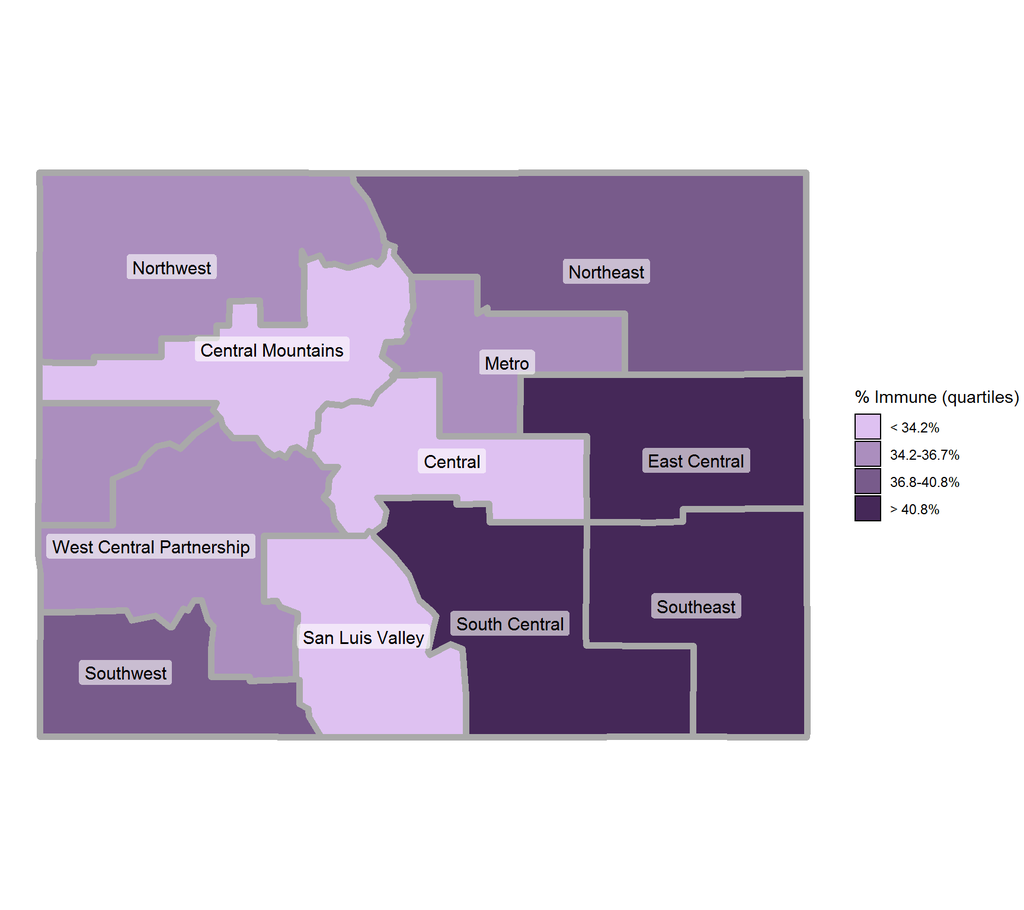

### **Effective Reproductive Number**

The figure below shows the estimated effective reproductive number for each region since March.

The effective reproduction number (Re) is a measure of how rapidly infections are spreading or declining in a region at a given point in time. When the effective reproductive number is below 1, infections are decreasing. When the effective reproductive number is above 1, infections are increasing.

The effective reproductive number is estimated using our age-structured meta-population model fit to hospitalization data. Because we base our parameter estimates primarily on COVID-19 hospitalization data, and hospitalizations today generally reflect infections occurring approximately 13 days prior, our most recent estimates of the effective reproductive number likely reflect the spread of infections occurring on approximately 04/13/2021.

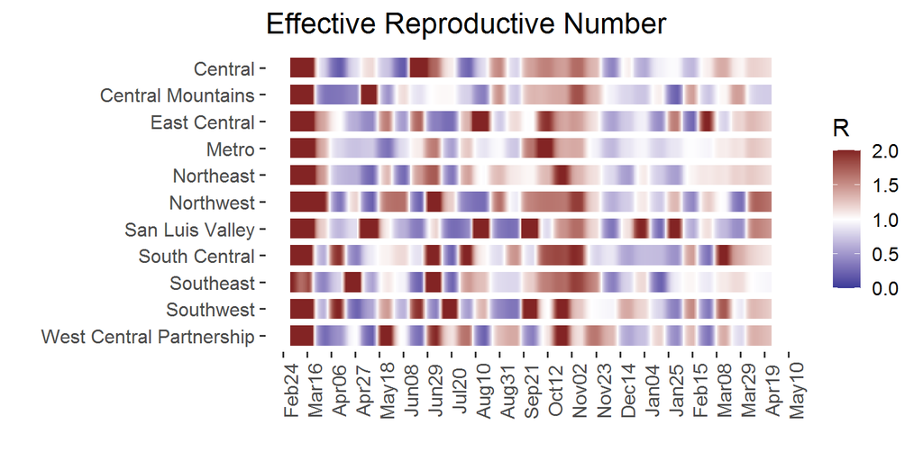

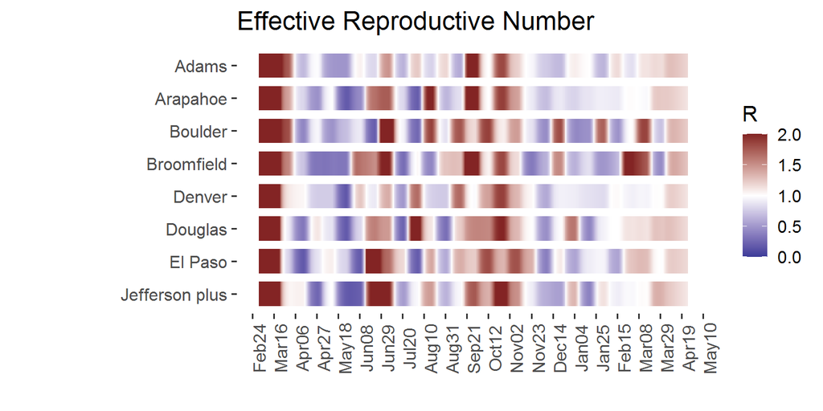

**Figure 4.** Estimated effective reproductive number (Re) over time in the 11 LPHA regions in Colorado, and 8 selected counties and county clusters. Estimates shown using COVID-19 hospitalization data through 04/26/2021.

### **Infection prevalence**

Infection prevalence provides an estimate of the proportion of the population that is currently infected with SARS-CoV-2 and capable of spreading infections. At higher levels of infection prevalence, individuals are more likely to encounter infectious individuals among their contacts. Because many people experience no symptoms or mild symptoms of COVID-19, many infections are not identified by surveillance systems. The estimates we present here are intended to provide an approximation of all infections, including those not detected by the Colorado Electronic Disease Reporting System (CEDRS).

The figure below shows the estimated infection prevalence per 100,000 individuals for each region. These are estimated from the age-structured meta-population model.

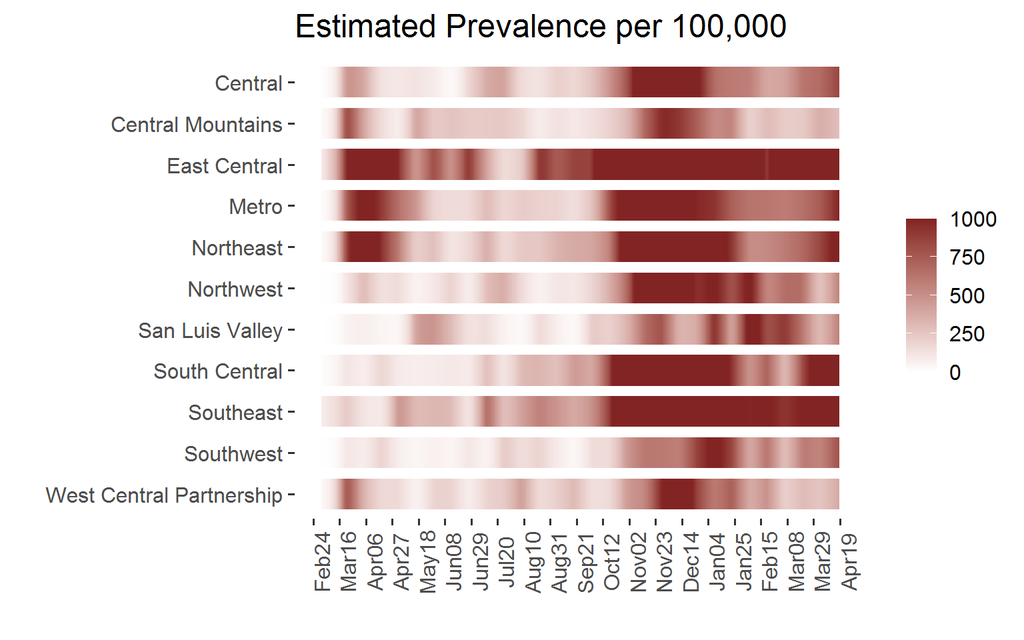

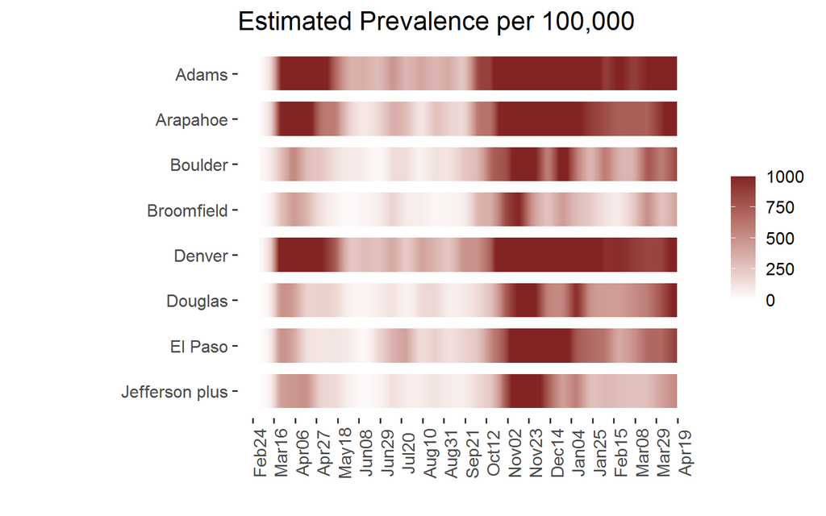

**Figure 5.** Estimated prevalence per 100,000 population for each of the 11 LPHA regions (top), plus the 8 selected counties and county clusters (bottom). All prevalence values over 1,000 per 100,000 are shown in dark red. Prevalence values estimated up to 04/19/2021.

### **COVID-19 hospitalizations**

The figures below show the daily number of individuals hospitalized with COVID-19 from each region. Hospitalization data are from the COVID Patient Hospitalization Surveillance (COPHS) maintained by the Colorado Department of Public Health and the Environment (CDPHE). Each COVID-19 patient is assigned to a region based on their home zip code. COVID-19 hospitalizations are shown per 100,000 population to allow comparability across regions.

COVID-19 hospitalizations are a sensitive measure of SARS-CoV-2 transmission and are an important indicator of the severity of infections in a region. While many SARS-CoV-2 infections are not captured by state surveillance systems, we expect that almost all COVID-19 hospitalizations are identified.

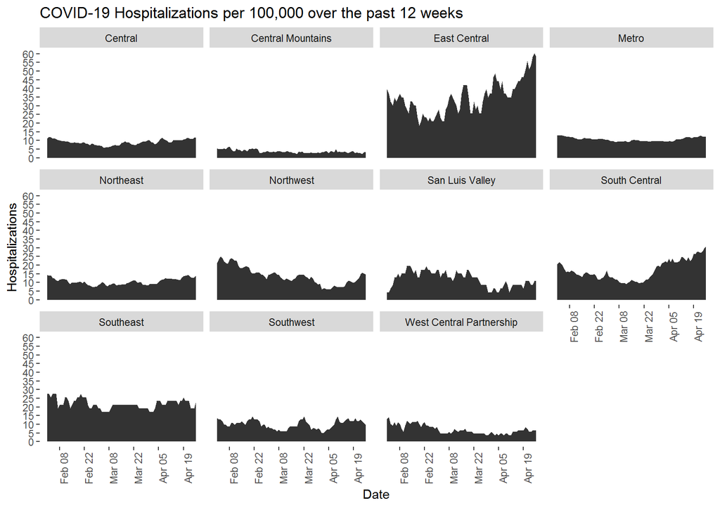

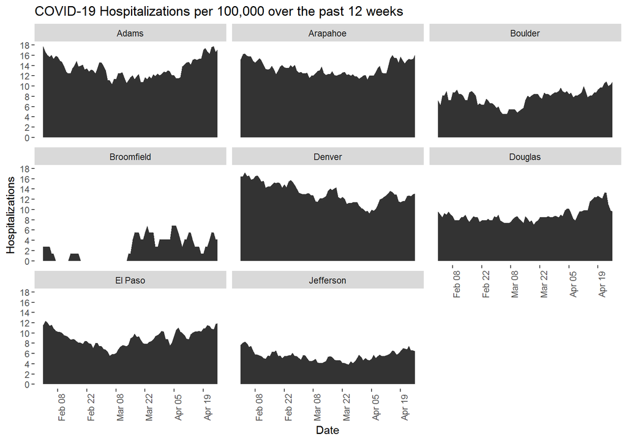

**Figure 6.** The daily number of people hospitalized with COVID-19 per capita for the 11 LPHA regions and the 8 selected counties and county clusters in Colorado over the past 12 weeks. Hospitalization data are from the COPHS hospital census data through 04/26/2021.

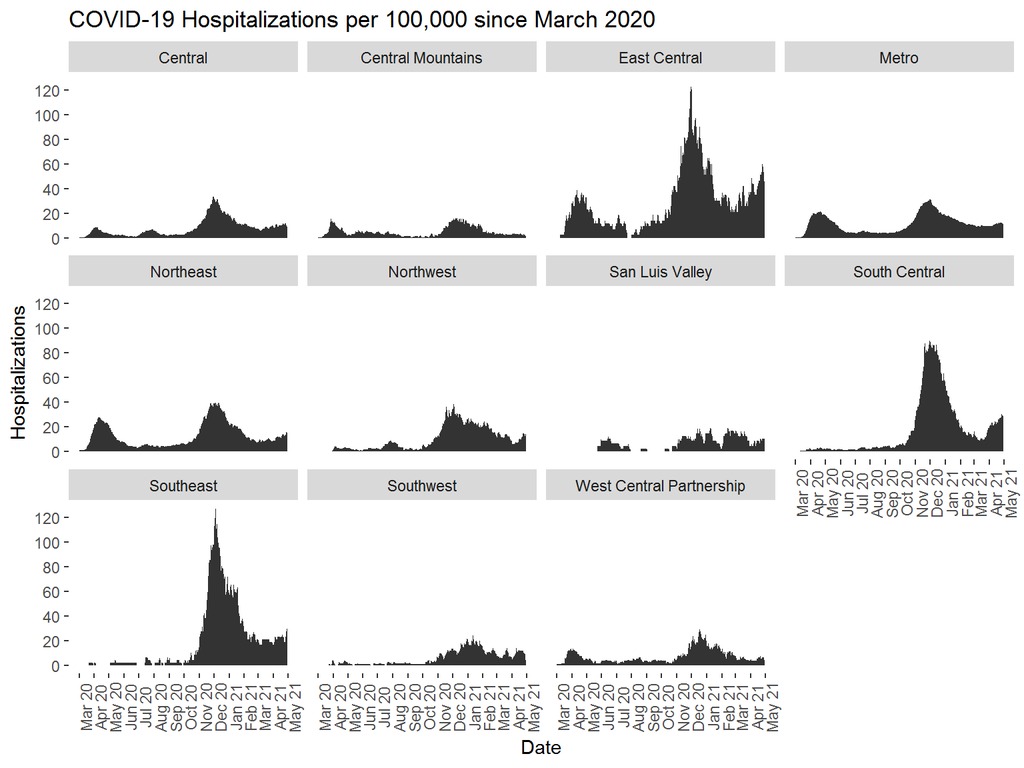

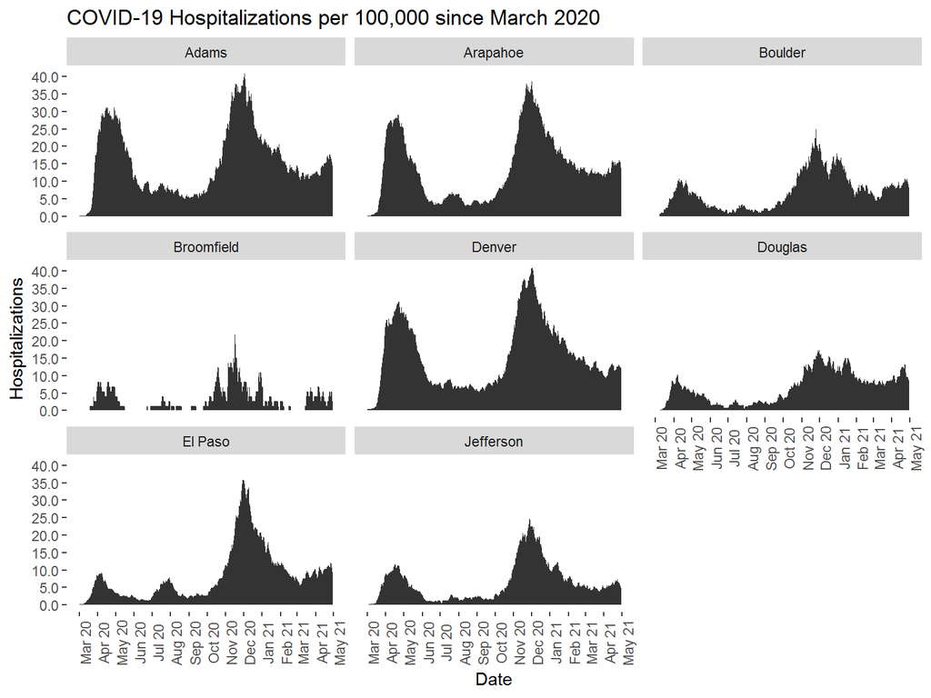

**Figure 7.** The daily number of people hospitalized with COVID-19 hospitalizations per capita for the 11 LPHA regions and the 8 selected counties and county clusters in Colorado since the first case was reported in March 2020. Hospitalization data are from the COPHS hospital census data through 04/26/2021.

### **Technical Summary**

Within the State of Colorado, as for other states, the spread of SARS-CoV-2 varies across the regions of the state, differing between urban and rural locations and resort and non-resort areas, for example. The modeling carried out by the Colorado COVID-19 Modeling Group was initiated at the state level providing a picture that does not give detail at the regional or county-level. Such detail is needed for public health planning and action.

To provide the needed detail, the Modeling Group developed regional-level models, using approaches similar to those for the overall Colorado model. To date, we have used scaled-down versions of the state-wide SEIR model to generate estimates of the effective reproductive number, infection prevalence, and the cumulative number of people infected in the 11 LPHA regions and 8 select counties with larger population size.

As of March 17, we have adopted a new model structure better suited to the current situation and anticipated needs in the months ahead. The new model is a meta-population model, which accounts for the flow of people between regions. The model structure that has been updated to account for the vaccine rollout. This new model structure will allow us to generate more robust estimates of the percent of the population immune (due to vaccination and/or prior infection). It will also harness real-time mobility data and allow us to account for travel between regions, which may contribute to the spread of SARS-CoV-2.

**What has changed?**

*For clarity, we refer to the new model as the meta-population model and the model that has been used to date as the regional SEIR models.*

**Connectivity.** The meta-population model accounts for population movement between regions which can lead to the spread of infections across the state. Population movement between regions is estimated using SafeGraph mobility data. In the model, infected individuals can travel to another region and spread infections. Similarly, uninfected individuals can travel to another region, acquire infection, and return to their home region and spread infections to their community. The regional SEIR model did not account for travel between regions.

**Immunity.** The meta-population model has updated assumptions about immunity to bring this in line with the state-level model. It is assumed individuals with symptomatic infections are immune for 360 days following infection and individuals with asymptomatic infections are immune for 180 days following infection based on growing scientific literature indicating SARS-CoV-2 immunity wanes over time. The regional SEIR models assumed life-long immunity.

**Vaccination.** The structure of the meta-population model has been updated to allow for vaccination. Individuals are moved into the vaccinated compartment based on county-specific vaccination data provided by CDPHE. Because we are provided total count of vaccinations by county, but not the age distribution of those vaccinations, we assume vaccines are distributed among the four age groups in proportion to the state-level age distribution for each time period.

**Hospitalization vs. case data.** In the meta-population model, we use COVID-19 hospitalization for model fitting. Case data is not used. In the regional SEIR model, we augmented hospitalization data with case data for model fitting in smaller LPHA regions (San Luis Valley, Southeast, Southwest, West Central Partnership) and counties (Broomfield). We continue to caution that estimates in these regions are subject to greater uncertainty due to small population sizes.

In addition, the basic SEIR structure has been updated to bring us in line with current modeling needs and to reflect the updated state-level model structure. As such, the meta-population model groups all COVID-19 hospitalizations together and does not longer include a separate ICU compartment.

With these changes, we are phasing out two estimates: cumulative number of infections to date and transmission control. Regarding the cumulative number of infections to date: Because immunity wanes over time, it is now theoretically possible for people to be infected more than once. Mathematically, this means we can no longer estimate the proportion infected to date as the cumulative number of infections divided by the population, and therefore are phasing out this estimate. We are also phasing out estimation of transmission control for each region, as the new model formulation does not include a transmission control parameter. Rather, the meta-population model defines a region-specific transmission rate (“beta-t”) that changes over time. In our prior formulation, we defined a fixed transmission rate (“beta”) for each region and an estimated a time-varying transmission control parameter that modulated the transmission rate (B(1-TC)). This change was made to allow us to include mobility in the model. We think the most important indicators of SARS-CoV-2 are estimated effective reproductive number, prevalence and the proportion of the population immune.

**Biweekly estimates.** We propose to start generating regional modeling reports biweekly. Since the fall, we have fit our models using a two-week definition of transmission control, and we now do the same with our time-varying beta. This two-week definition helps to minimize large swings in our estimates due to occasional noise in COVID-19 hospitalizations. However, this leads us to have “A” weeks, when we are fitting our last parameter to less than 14 days of data, and “B” weeks, when beta is fit to at least two weeks of data. Given the small size of some of the regions, we are planning to shift to generating model estimates in “B” weeks only. This will help minimize large swings in estimates between A and B weeks. This shift will allow us to generate more robust estimates. We are exploring whether a limited set of estimates based on hospitalizations, cases and/or mobility might be generating in during A weeks to allow us to detect major changes in the data.

**Methods.** We use data on COVID-19 hospitalizations, mobile-phone based mobility data and an age-structured meta-population model of SARS-CoV-2 transmission to estimate the current state of infections in each region. The model is similar in many ways to the state-wide model, in that it accounts for differences in the severity of infection by age and uses Colorado-specific demographic and clinical data. For example, the length of time a COVID-19 patient spends in the hospital varies by age and is based on data provided by Colorado hospitals. A full description of the model and estimation approaches are provided in the documentation, available [here](https://agb85.github.io/covid-19/SEIR%20Documentation.pdf). Prior modeling reports and documentation can be found [here](https://agb85.github.io/covid-19/).

**Data Sources:** COVID-19 hospitalizations are obtained from COPHS reported through 04/30/2021.Due to lags in reporting, these data are cleaved 4 days prior such that hospitalizations through 04/26/2021 are used in modeling and shown in this report. SARS-CoV-2 vaccination data by county are provided by CDPHE weekly. Age distribution of vaccination by region is inferred from state-level age distribution data.

Case data are based on CEDRS through 05/01/2021. Due to lags in reporting, these data are cleaved ten days prior on 04/21/2021. These data sources are provided by CDPHE.

**Limitations:** The model results are subject to greater uncertainty than those for the entire state because there are fewer hospitalizations in each region than in the state as a whole. Estimates are most uncertain for the regions with the smallest population size. This model uses real-time mobility to account for the flow of populations between regions. It remains an open question in the scientific community how to use measures of population movement to accurately model the spread of infections.

| Region | Population | Counties |
| --- | --- | --- |
| **LPHA Regions** |  |  |
| Central | 810,420 | Chaffee, El Paso, Lake, Park, Teller |
| Central Mountains | 182,689 | Eagle, Garfield, Grand, Pitkin, Summit |
| East Central | 43,032 | Cheyenne, Elbert, Kit Carson, Lincoln |
| Metro | 3,291,794 | Adams, Arapahoe, Boulder, Broomfield, Clear Creek, Denver, Douglas, Gilpin, Jefferson* |
| Northeast | 765,265 | Larimer, Logan, Morgan, Phillips, Sedgwick, Washington, Weld, Yuma |
| Northwest | 203,301 | Jackson, Mesa, Moffat, Rio Blanco, Routt |
| San Luis Valley | 46,472 | Alamosa, Conejos, Costilla, Rio Grande, Saguache |
| South Central | 243,196 | Custer, Fremont, Huerfano, Las Animas, Pueblo |
| Southeast | 46,938 | Baca, Bent, Crowley, Kiowa, Otero, Prowers |
| Southwest | 102,154 | Archuleta, Dolores, La Plata, Montezuma, San Juan |
| West Central Partnership | 106,839 | Delta, Gunnison, Hinsdale, Mineral, Montrose, Ouray, San Miguel |
| **Eight select counties** |  |  |
| Adams | 528,857 | Adams |
| Arapahoe | 664,988 | Arapahoe |
| Boulder | 330,978 | Boulder |
| Broomfield | 72,827 | Broomfield |
| Denver | 737,854 | Denver |
| Douglas | 354,331 | Douglas |
| El Paso | 737,354 | El Paso |
| Jefferson plus | 601,959 | Clear Creek, Gilpin, Jefferson |

**Table 2:** Description of the regions used in this report, including the 11 LPHA Regions. Population estimates are based on 2020 US Census Projections provided by the Colorado Demography Office.

*Clear Creek, Gilpin Counties and Jefferson counties are modeled as a single unit due to the small population of Clear Creek (9,379 residents) and Gilpin (5,924 residents) – populations too small to allow for stable estimation.

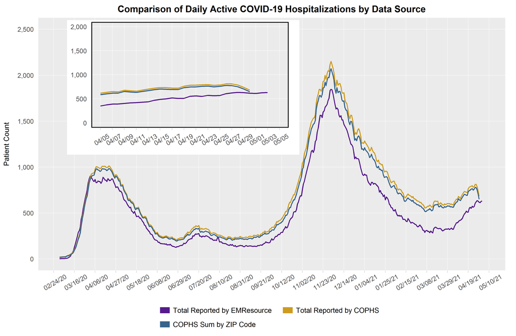

**Figure 8.** Comparison of daily active COVID-19 hospitalizations by data source.

*The COPHS data were updated in late December to include records that had previously been unreported. At present, the COPHS dataset now estimates more hospitalizations on a given day than EMResources. Because both data sources show the same trend (e.g., both increase and decrease together), this should not impact our estimates of the effective reproductive number. However, the addition of previously unreported records will lead estimates of infection prevalence to be higher in some regions on a given day than they were previously. We have updated the estimates of prevalence since March and these can be viewed in the region and county-specific estimates, allowing apples to apples comparison of changes in prevalence over time.